# Assignment Week 11

Bohan Zhang

2025-05-19

```r
suppressPackageStartupMessages({
  library(epiwraps)
  library(ggplot2)
  library(AnnotationHub)
  library(ensembldb)
  library(edgeR)
  library(rtracklayer)
  library(BiocParallel)
  library(rGREAT)
  library(bsseq)   # Class and tools to analyze bisulfite sequencing data at CpG-level
  library(DMRcate) # Identification of differentially-methylated regions
})
setwd("/mnt/gapp/work/bohan/bioinfo/Week11")
```

## Data Preparation

```r
#download.file("https://github.com/ETHZ-INS/ethEpigen2025_materials/blob/main/week11/dmr.rds", "dmr.rds")
dmr <- readRDS("dmr.rds")
dmr <- dmr[!is.na(dmr$overlapping.genes),] #remove those without gene names
dmr <- dmr[order(dmr$min_smoothed_fdr),]
dmr_chr1 <- dmr[seqnames(dmr)=="chr1",]

bs <- readRDS("ESC_astrocytes_BSseq.rds")
# remove CpGs that have 0 coverage in some samples:
bs <- bs[rowSums(assay(bs,"Cov")>0)==ncol(bs),]
bs <- BSmooth(bs, BPPARAM=MulticoreParam(4, progress=TRUE))
```

[output not shown]

## Heatmap of top20 DMRs on chr1

```r
top20 <- head(dmr_chr1, n = 20)
top20
```

```
## GRanges object with 20 ranges and 8 metadata columns:
##        seqnames              ranges strand |   no.cpgs min_smoothed_fdr
##           <Rle>           <IRanges>  <Rle> | <integer>        <numeric>
##    [1]     chr1     2706052-2706636      * |        37      0.00000e+00
##    [2]     chr1 207818394-207818642      * |        19     2.24056e-271
##    [3]     chr1 248020764-248020939      * |        23     2.63274e-264
##    [4]     chr1     9099280-9100561      * |        43     9.42756e-187
##    [5]     chr1   36644004-36644469      * |        24     3.22663e-159
##    ...      ...                 ...    ... .       ...              ...
##   [16]     chr1   25240876-25240995      * |        10      1.56277e-84
##   [17]     chr1     2979275-2981019      * |        33      1.99898e-83
##   [18]     chr1 230993054-230993133      * |         6      1.82406e-77
##   [19]     chr1     2253765-2254684      * |        25      2.68333e-75
##   [20]     chr1   36641686-36642103      * |        27      1.52766e-74
##            Stouffer       HMFDR       Fisher   maxdiff  meandiff
```

[output cut: 27 more lines]

```r
met_top20 <- bsseq::getMeth(bs, regions=top20, what="perRegion")
colnames(met_top20) <- colnames(bs)
rownames(met_top20) <- top20$overlapping.genes
met_top20
```

```
##                    astrocytes_ENCFF001TPN astrocytes_ENCFF001TPP
## TTC34                          0.08698892             0.09894437
## CR1L, CD46P1                   0.13152748             0.04721327
## TRIM58                         0.10091849             0.08869887
## SLC2A5                         0.05088977             0.08708031
## MAP7D1                         0.60702168             0.76873665
## LACTBL1                        0.17246819             0.05893228
## TRIM67                         0.02729095             0.02989803
## GJC2                           0.09223514             0.18735528
## GPR25                          0.24332062             0.29772496
## SEMA6C                         0.41073400             0.60535971
## PRKCZ                          0.36418084             0.39934020
## RP11-54O7.16                   0.23750017             0.15772096
## FLG-AS1                        0.23597890             0.32871385
## CR1L                           0.40612149             0.14398379
## ELF3, RP11-465N4.4             0.44993283             0.53390637
## RUNX3                          0.20450827             0.33023647
## LINC00982                      0.58880450             0.56573874
## C1orf198                       0.13292343             0.08008372
## MORN1                          0.20437810             0.21962479
## MAP7D1                         0.29986661             0.68140790
##                    ESC_ENCFF001TMC ESC_ENCFF001TMD
## TTC34                   0.95660776      0.95023823
## CR1L, CD46P1            0.92591359      0.90974509
## TRIM58                  0.84996318      0.83490487
## SLC2A5                  0.93754587      0.89600461
## MAP7D1                  0.08045465      0.07431719
## LACTBL1                 0.70496694      0.65785429
## TRIM67                  0.30857585      0.34035357
## GJC2                    0.86221610      0.80515136
## GPR25                   0.88778621      0.88294550
## SEMA6C                  0.10924610      0.08071723
## PRKCZ                   0.92052625      0.91569729
## RP11-54O7.16            0.82513182      0.77615677
## FLG-AS1                 0.94086305      0.93153193
## CR1L                    0.84671049      0.85641581
## ELF3, RP11-465N4.4      0.19937389      0.19656007
## RUNX3                   0.85081618      0.78631798
## LINC00982               0.10694070      0.09709496
## C1orf198                0.64375812      0.73716494
## MORN1                   0.74355190      0.74827170
## MAP7D1                  0.04934198      0.03746201
```

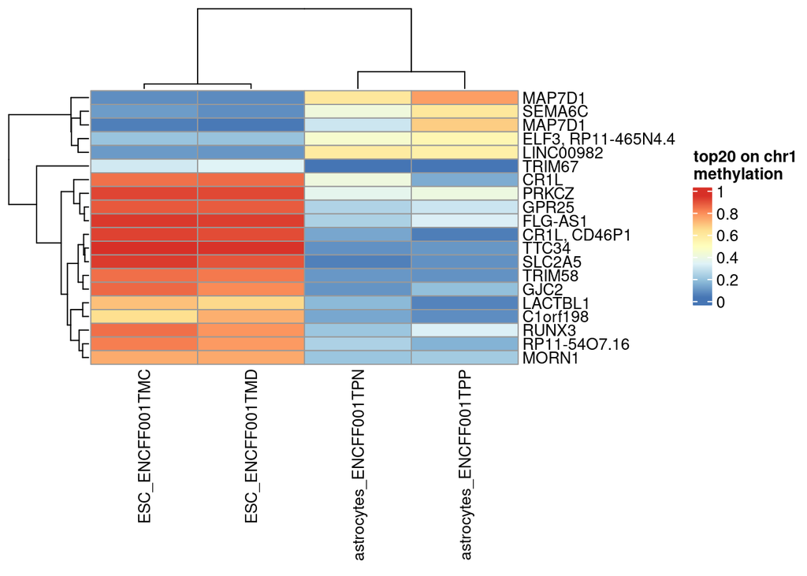

```r
pheatmap(met_top20, name="top20 on chr1\nmethylation")
```

We can see a clear pattern that some genes have higher methylation level in ESC, while some genes have higher methylation level in astrocytes. Meanwhile, there is a duplicated gene (MAP7D1). The two DMRs are very close.

## rGREAT analysis

```r
enrich <- submitGreatJob(
  gr = dmr,
  species = "hg19"
)
```

```
## Note: On Aug 19 2019 GREAT released version 4 which supports hg38
## genome and removes some ontologies such pathways. submitGreatJob()
## still takes hg19 as default. hg38 can be specified by argument `genome
## = "hg38"`. To use the older versions such as 3.0.0, specify as
## submitGreatJob(..., version = "3"). Set argument `help` to `FALSE` to
## turn off this message.
```

```r
result <- getEnrichmentTables(enrich)
```

```
## The default enrichment table does not contain informatin of associated
## genes for each input region. You can set `download_by = 'tsv'` to
## download the complete table, but note only the top 500 regions can be
## retreived. See the following link:
##
## https://great-help.atlassian.net/wiki/spaces/GREAT/pages/655401/Export#Export-GlobalExport
##
## Except the additional gene-region association column if taking 'tsv' as
## the source of result, all other columns are the same if you choose
## 'json' (the default) as the source. Or you can try the local GREAT
## analysis with the function `great()`.
```

```r
head(result$`GO Molecular Function`, n = 10)
```

```
##            ID                                                       name
## 1  GO:0051525                                       NFAT protein binding
## 2  GO:0047066 phospholipid-hydroperoxide glutathione peroxidase activity
## 3  GO:0048018                                  receptor agonist activity
## 4  GO:0005488                                                    binding
## 5  GO:0097371                           MDM2/MDM4 family protein binding
## 6  GO:0004886                      9-cis retinoic acid receptor activity
## 7  GO:0005089             Rho guanyl-nucleotide exchange factor activity
## 8  GO:0070644                         vitamin D response element binding
## 9  GO:0008332                 low voltage-gated calcium channel activity
## 10 GO:0042165                                   neurotransmitter binding
##    Binom_Genome_Fraction Binom_Expected Binom_Observed_Region_Hits
## 1           0.0002477656   4.655516e-01                         10
## 2           0.0000259832   4.882243e-02                          5
## 3           0.0028534490   5.361630e+00                         24
```

[output cut: 51 more lines]

```r
head(result$`GO Biological Process`, n = 10)
```

```
##            ID
## 1  GO:0072364
## 2  GO:0035095
## 3  GO:0060482
## 4  GO:0014807
## 5  GO:0072363
## 6  GO:0072366
## 7  GO:0072369
## 8  GO:0016332
## 9  GO:0072060
## 10 GO:0003192
##                                                                                                                       name
## 1           regulation of cellular ketone metabolic process by regulation of transcription from RNA polymerase II promoter
## 2                                                                                          behavioral response to nicotine
## 3                                                                                               lobar bronchus development
```

[output cut: 62 more lines]

```r
head(result$`GO Cellular Component`, n = 10)
```

```
##            ID                              name Binom_Genome_Fraction
## 1  GO:0005623                              cell          0.9165759000
## 2  GO:0044464                         cell part          0.9162713000
## 3  GO:0044424                intracellular part          0.8356126000
## 4  GO:0005622                     intracellular          0.8477178000
## 5  GO:0017053 transcriptional repressor complex          0.0092964810
## 6  GO:0005796                       Golgi lumen          0.0107514200
## 7  GO:0043229           intracellular organelle          0.7701666000
## 8  GO:0043226                         organelle          0.8114346000
## 9  GO:0002193    MAML1-RBP-Jkappa- ICN1 complex          0.0002916474
## 10 GO:0005788       endoplasmic reticulum lumen          0.0279188300
##    Binom_Expected Binom_Observed_Region_Hits Binom_Fold_Enrichment
## 1    1722.2460000                       1806              1.048631
## 2    1721.6740000                       1804              1.047818
## 3    1570.1160000                       1682              1.071258
```

[output cut: 51 more lines]

What the enrichment analysis is testing: For each GO term, GREAT counts how many DMRs fall within the gene regulatory domain defined by that term; and the proportion of intervals in the entire background (here is the whole genome) that are associated with that term. Simply put, it tests whether DMR appears more frequently than randomly in the gene regulatory domain corresponding to the known functional annotations (GO term).

The results (for each category, three terms are chosen to be interpreted):

For Molecular Function:

- NFAT protein binding: NFAT (Nuclear Factor of Activated T-cells) is a type of calcium-sensitive transcription factor that is classic in immune cells but also has a regulatory role in the development and plasticity of the nervous system.
- phospholipid-hydroperoxide glutathione peroxidase activity: An antioxidant enzyme that reduces lipid peroxides on membranes and protects cells from oxidative damage. Antioxidant defense is particularly important in astrocytes. Altered methylation in the relevant gene regions suggests epigenetic remodeling of the regulation of the GPx4 system or oxidative stress response in astrocytes.
- 9-cis retinoic acid receptor activity: After binding to 9-cis retinoic acid, Retinoid X Receptor (RXR) heterodimerizes and regulates downstream gene expression, and is widely involved in development and differentiation. RXR signaling is an important component of nervous system development and glial cell function maintenance. DMR enrichment in its target gene regulatory region suggests that the retinoic acid pathway is involved in astrocyte directional differentiation.

For Biological Process:

- behavioral response to nicotine: Astrocytes express multiple nicotinic acetylcholine receptors; methylation changes in genes related to nicotine response during differentiation may affect the involvement of glial cells in toxicant response and neuroprotection.
- regulation of glycolytic process by positive regulation of transcription from RNA polymerase II promoter: ESCs are more dependent on glycolysis, while astrocytes still have strong glycolytic capabilities in their mature state; changes in DMR methylation on the promoters of key enzyme genes (such as HK2 and PFK) indicate that the expression of glycolytic genes is finely regulated during differentiation.
- regulation of cellular ketone metabolic process by regulation of transcription from RNA polymerase II promoter: During differentiation from ESC to astrocyte, energy metabolism may shift from being dominated by glycolysis to being more dependent on fatty acid and ketone body utilization; DMR occurs in the promoter region that controls the transcription of such metabolic genes, suggesting that ketone body metabolism is subject to epigenetic regulation.

For Cellular Component (Basically they are broader terms):

- Golgi lumen: Astrocytes synthesize and secrete a large amount of proteins that support neurons (such as neurotrophic factors and cytokines). The epigenetic regulation of Golgi function affects these secretory pathways.
- MAML1–RBP-Jκ–ICN1 complex: Notch pathway plays a key role in neural development and glial cell differentiation
- endoplasmic reticulum lumen: Astrocyte calcium signaling events (such as calcium waves) and the production of a large number of secretory proteins are inseparable from the function of ER. The distribution of DMRs in the regulatory regions of related genes may affect the expression level and functional status of ER-related proteins.